# Histidine

Michael Bennett

2022-05-13

# S. aureus

**Backbone 1H, 13C, and 15N Chemical Shift Assignments for Histidine Kinase NsaS from S. aureus**

- Structure and Function of the Transmembrane Domain of NsaS, an Antibiotic Sensing Histidine Kinase in Staphylococcus aureus.

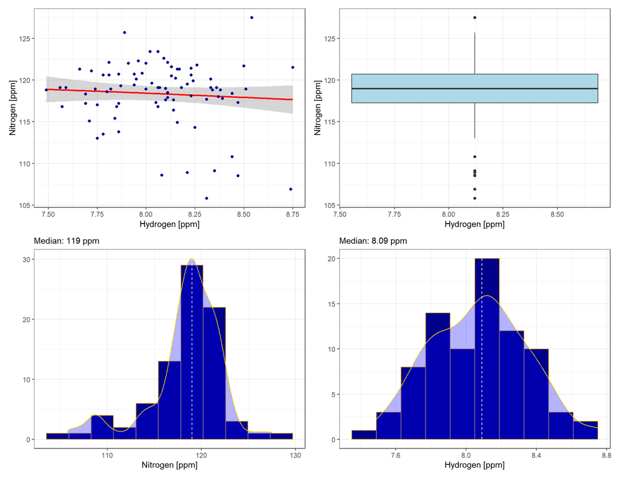

# S. carnosus

**1H, 13C, and 15N Chemical Shift Assignments for I14A mutant of histidine-containing phosphocarrier protein from Staphylococcus carnosus**

- Solution structure of the active-centre mutant I14A of the histidine-containing phosphocarrier protein from Staphylococcus carnosus

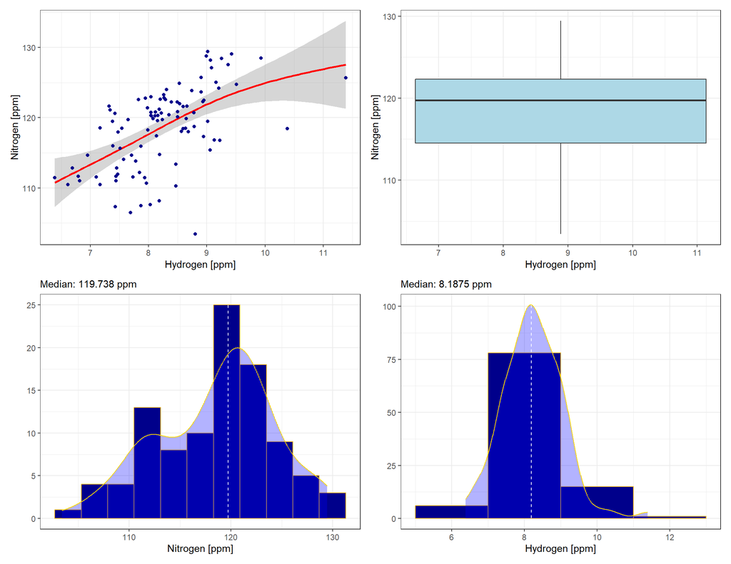

# E. coli

**Backbone chemical shifts from E. coli HisJ complexed with Histidine**

- Role of the Two Structural Domains from the Periplasmic Escherichia coli Histidine-binding Protein HisJ.

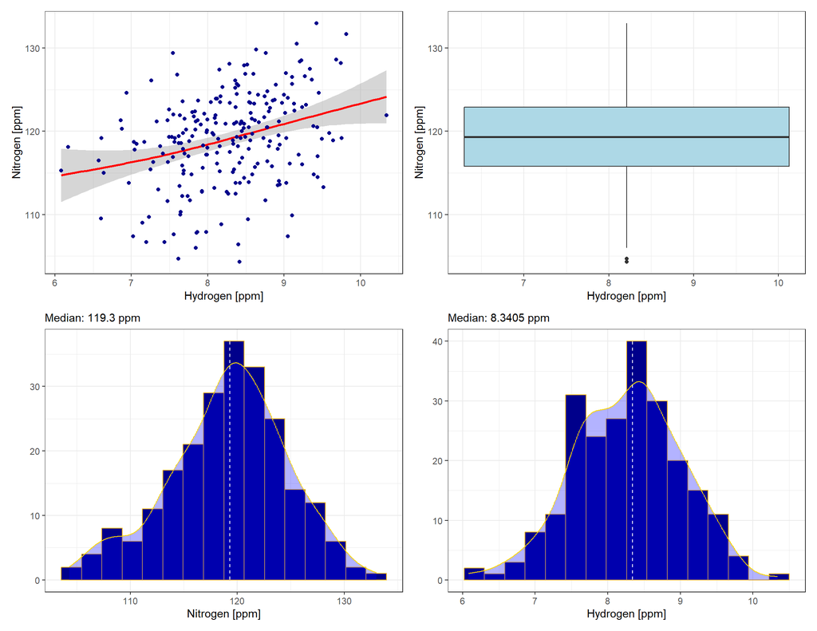

**Backbone chemical shifts of isolated Domain 2 from E. coli HisJ**

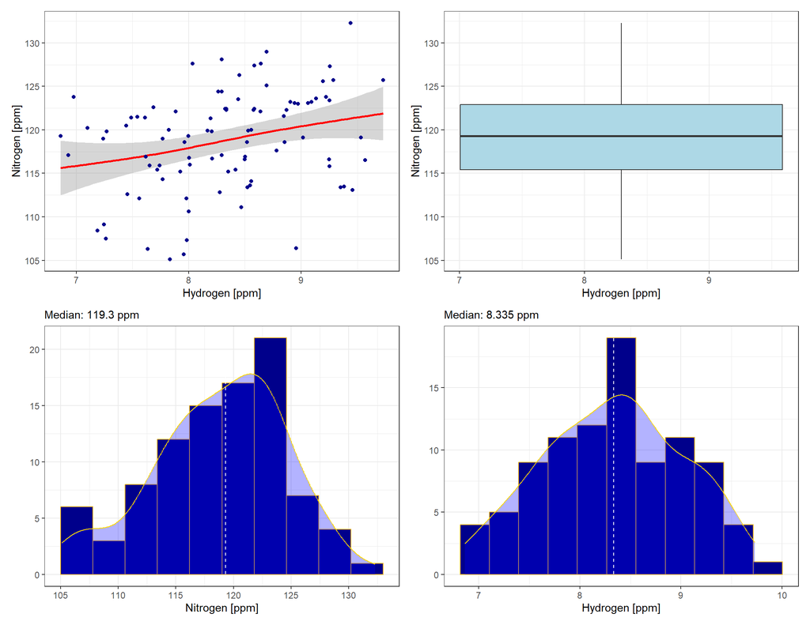

**Backbone chemical shifts of isolated Domain 1 from E. coli HisJ**

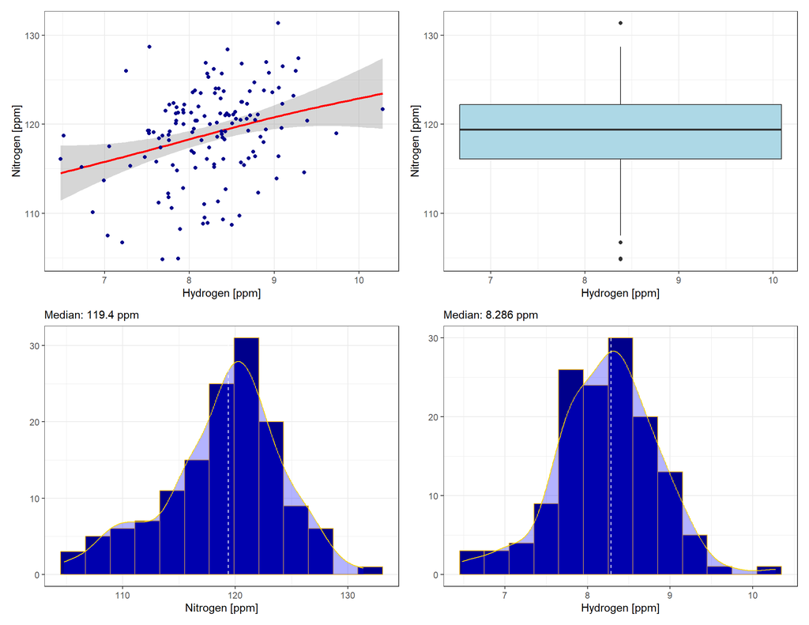

**Backbone 1H, 13C, and 15N Chemical Shift Assignments for apo HisJ and holo HisJ**

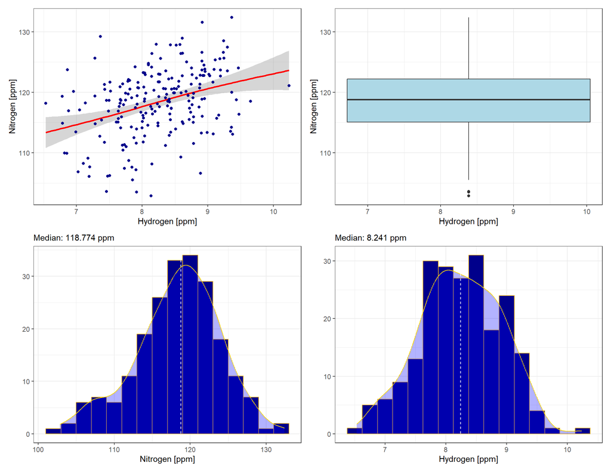

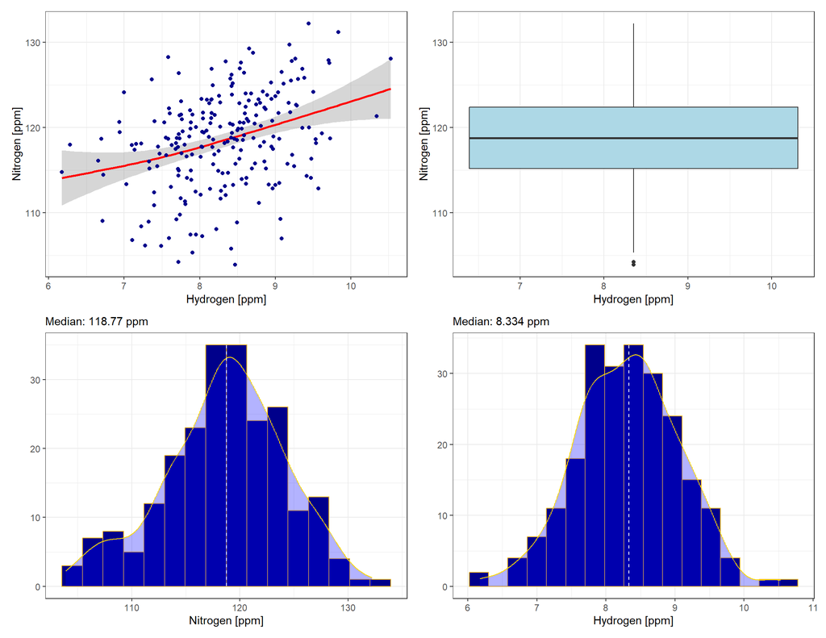

**1H, 13C, and 15N Chemical Shift Assignments for YojN-HPt**

- Assignment of 1H, 13C and 15N resonances of the Escherichia coli YojN Histidine-Phosphotransferase (HPt) domain.

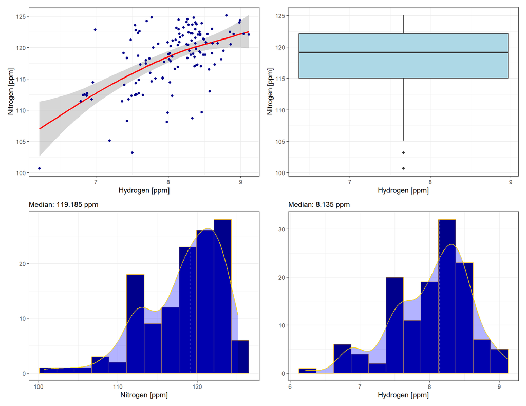

# C. crescentus

**Backbone 1H, 13C, 15N chemical shift assignments for the ShkA kinase Rec2 domain from Caulobacter crescentus**

- Hybrid Histidine kinase activation by cyclic-di-GMP induced domain liberation

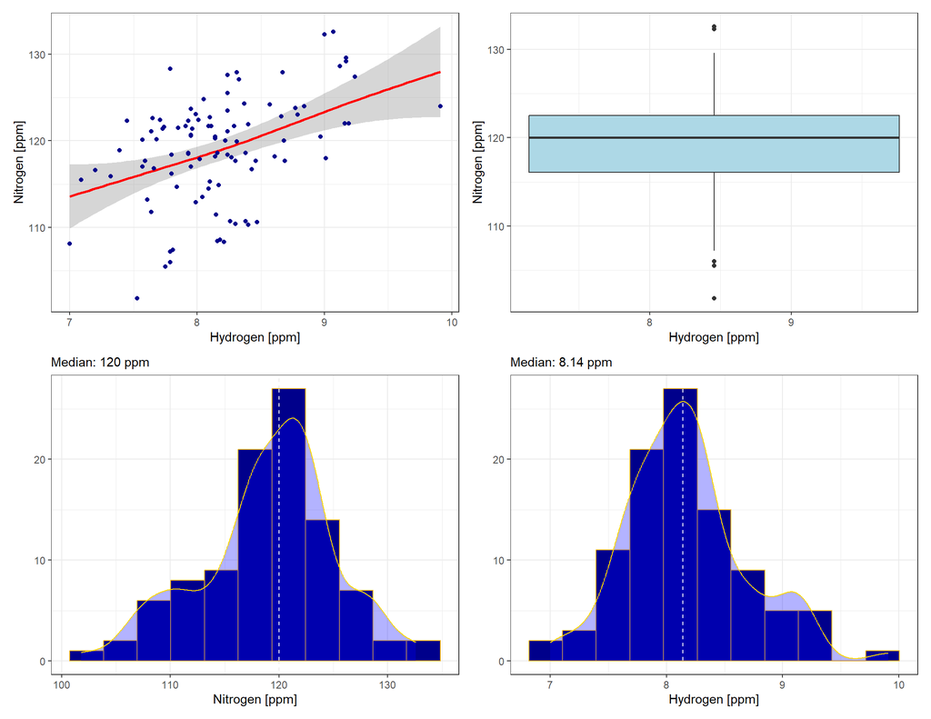

# P. aeruginosa

**1H, 13C, and 15N Chemical Shift Assignments for the periplasmic domain of GacS histidine-kinase**

- NMR assignments of the GacS histidine-kinase periplasmic detection domain from Pseudomonas aeruginosa PAO1

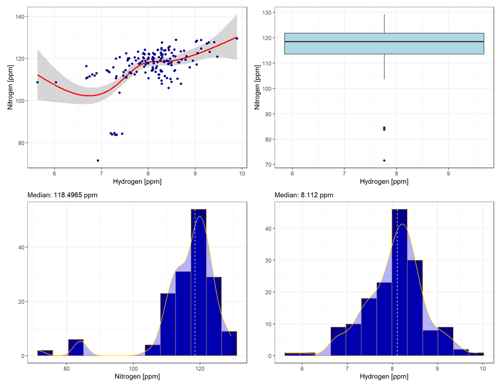

# Stress-related acidosis

**Chemical shift assignments and structure of the alpha-crystallin domain from human, HSPB5**

- A conserved histidine modulates HSPB5 structure to trigger chaperone activity in response to stress-related acidosis

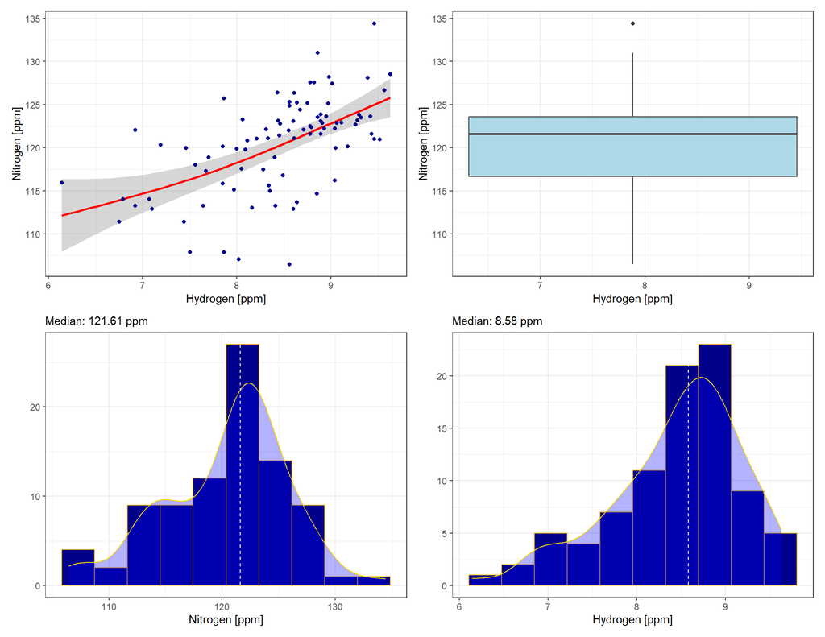

# Pin1 Gene

**Backbone 1H, 13C, and 15N Chemical Shift Assignments for the peptidyl prolyl cis-trans isomerase domain of human Pin1 without sulfate ion**

- The C113D mutation in human Pin1 causes allosteric structural changes in the phosphate binding pocket of the PPIase domain through the tug of war in the dual-histidine motif.

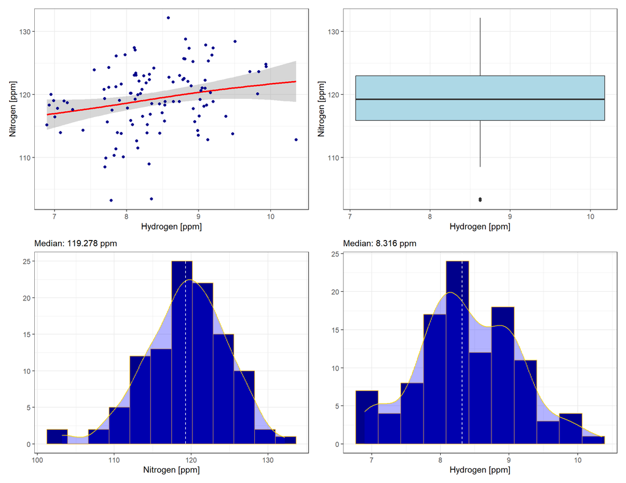

**Backbone 1H, 13C, and 15N Chemical Shift Assignments for the peptidyl prolyl cis-trans isomerase domain of C113D mutant human Pin1 without sulfate ion**

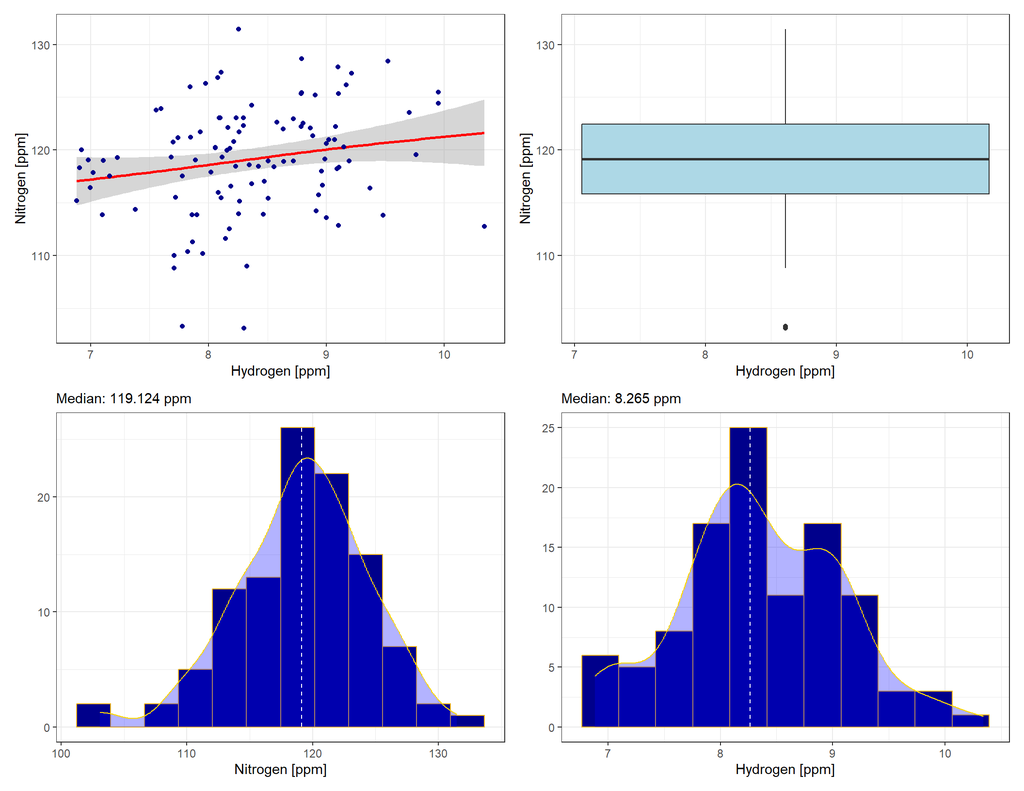

# T. maritima

**1H, 13C and 15N Chemical Shift Assignments for the CheA P1 domain from Thermotoga maritima**

- Chemical-shift-perturbation mapping of the phosphotransfer and catalytic domain interaction in the histidine autokinase CheA from Thermotoga maritima.

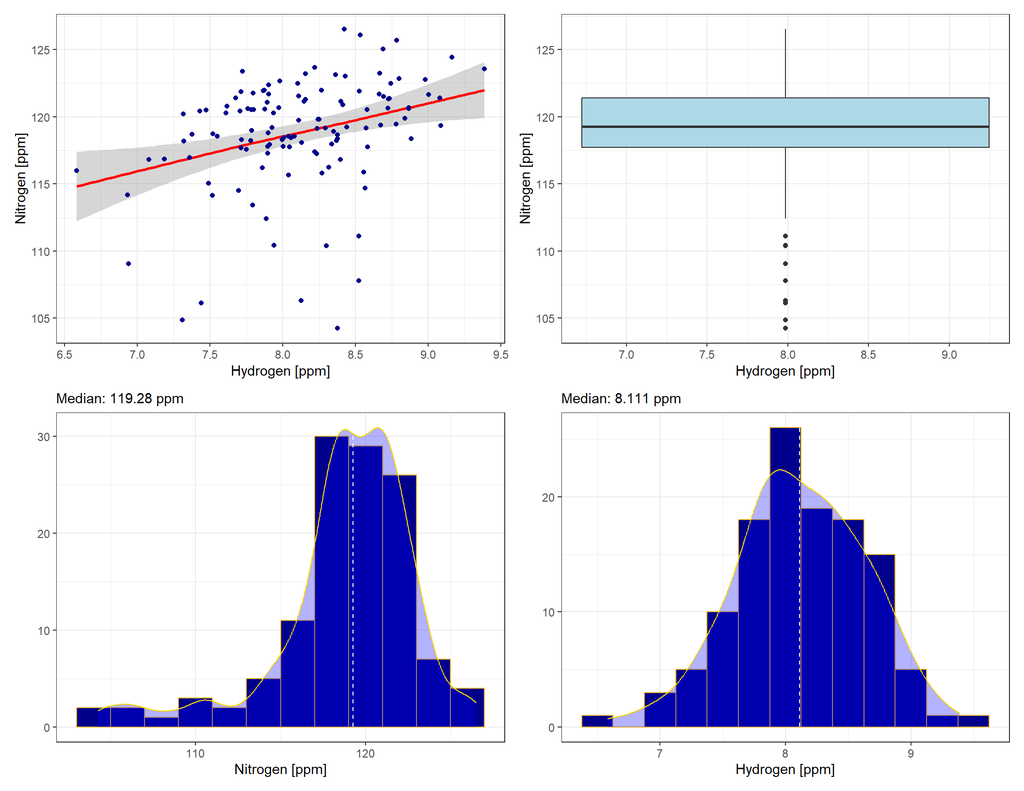

**Backbone 1H and 15N Chemical Shift Assignments for the CheA P4 domain from Thermotoga maritima, in the context of a P3P4 construct**

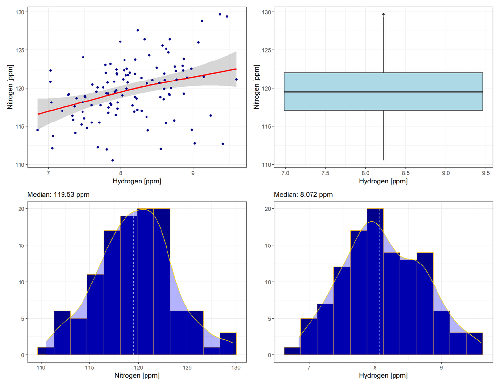

# PriB

**Backbone 1H, 13C, and 15N Chemical Shift Assignments for PriB**

- Involvement of histidine in complex formation of PriB and single-stranded DNA

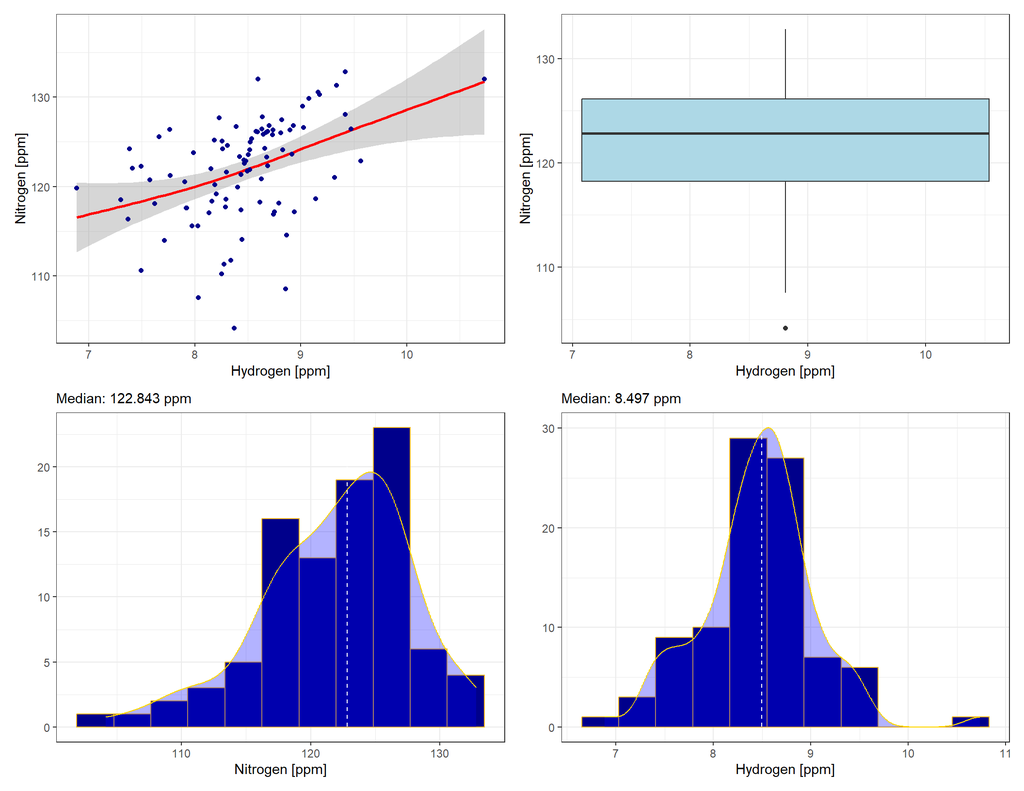

# B. pseudomallei

**Backbone chemical shift assignments for the sensor domain of the Burkholderia pseudomallei histidine kinase RisS. Seattle Structural Genomics Center for Infectious Disease target BupsA.00863.i.**

- Backbone chemical shift assignments for the sensor domain of the Burkholderia pseudomallei histidine kinase RisS - An “invisible” dimer interface.

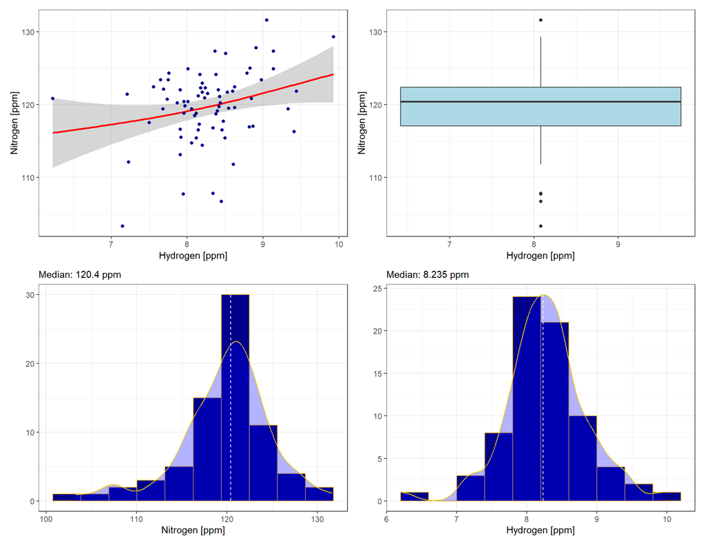

# HINT1 protein

**1H and 15N chemical shift assignments for HINT1 protein**

- Backbone assignment of HINT1 protein, a mouse histidine triad nucleotide binding protein

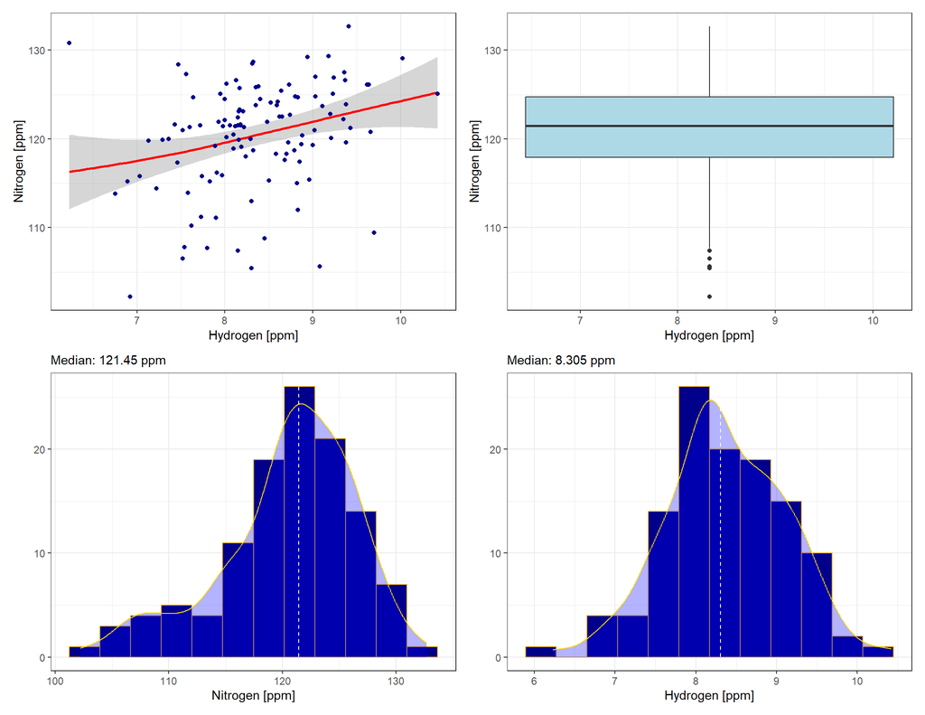

# D. crassirhizoma

**Backbone 1H and 15N chemical shift assignments of D. crassirhizoma Plastocyanin**

- Protonation of a histidine copper ligand in fern plastocyanin

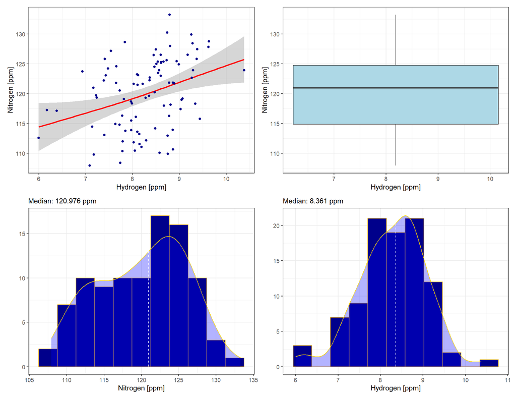

# Plastocyanin

**Characterization of us-ms Dynamics of Proteins Using a Combined Analysis of 15N NMR Relaxation and Chemical Shift: Conformational Exchange in Plastocyanin Induced by Histidine Protonations**

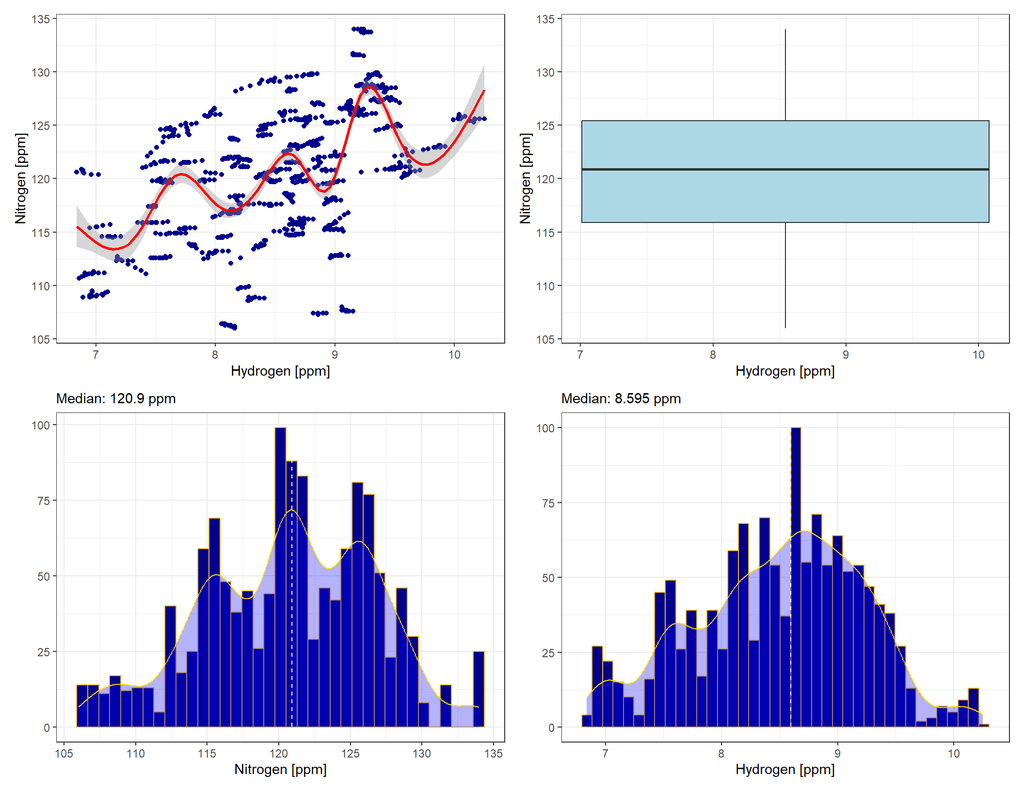

# LuxU protein

**1H, 15N, and 13C chemical shift assignments of the Vibrio Harveyi histidine phosphotransferase protein LuxU**

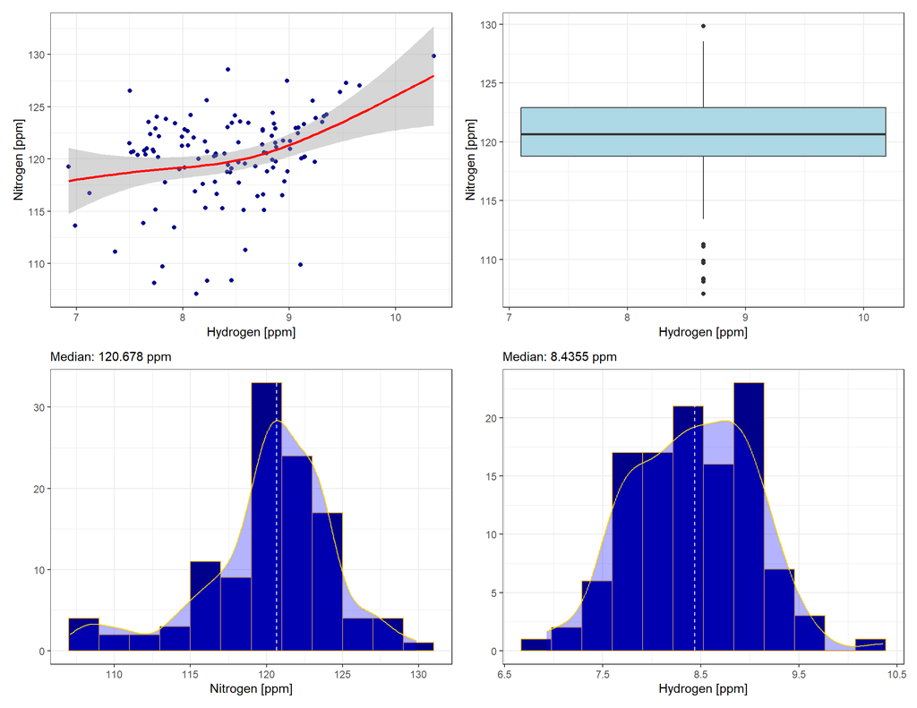

# B. subtilis

**Backbone and sidechain 1H, 13C, and 15N chemical shifts for Sda**

- Structure and mechanism of action of Sda, an inhibitor of the histidine kinases that regulate initiation of sporulation in Bacillus subtilis

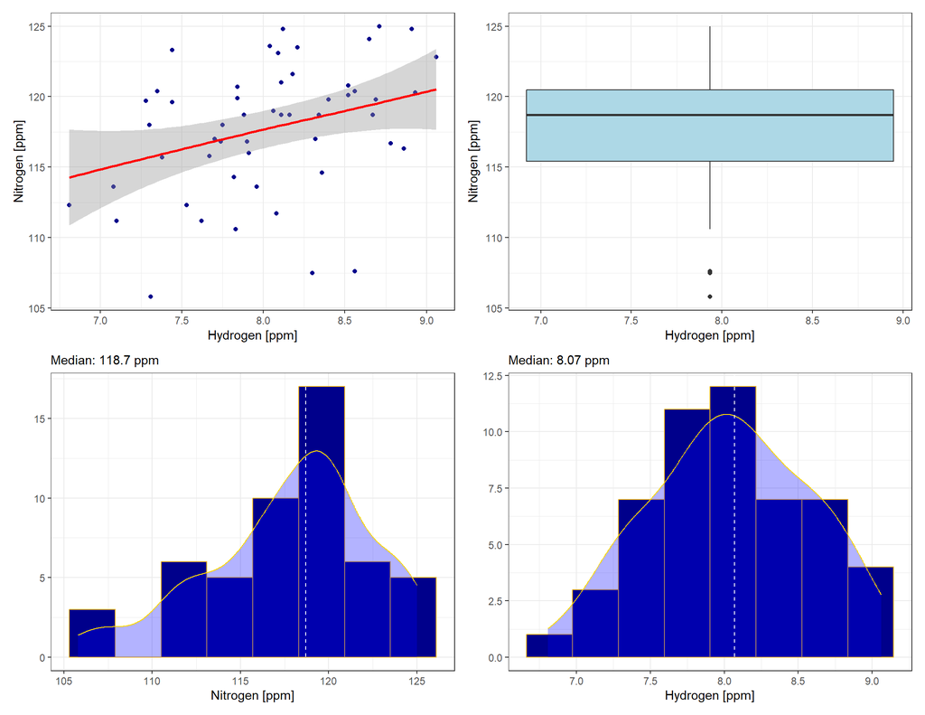